# Risk Factor Analysis

## Outcome Variable

**Outcome Variable:** whz

## Predictor Variables

**Intervention Variable:** month

**Adjustment Set:**

unadjusted

## Stratifying Variables

The analysis was stratified on these variable(s):

- agecat

## Data Summary

| agecat | month | n_cell | n | outcome_variable |
| --- | --- | --- | --- | --- |
| Birth | 1 | 4113 | 52405 | whz |
| Birth | 2 | 3838 | 52405 | whz |
| Birth | 3 | 4455 | 52405 | whz |
| Birth | 4 | 3911 | 52405 | whz |
| Birth | 5 | 3438 | 52405 | whz |
| Birth | 6 | 3740 | 52405 | whz |
| Birth | 7 | 4319 | 52405 | whz |
| Birth | 8 | 4696 | 52405 | whz |
| Birth | 9 | 4956 | 52405 | whz |
| Birth | 10 | 4863 | 52405 | whz |
| Birth | 11 | 4871 | 52405 | whz |
| Birth | 12 | 5205 | 52405 | whz |
| 6 months | 1 | 4335 | 57493 | whz |
| 6 months | 2 | 3891 | 57493 | whz |
| 6 months | 3 | 4603 | 57493 | whz |
| 6 months | 4 | 4667 | 57493 | whz |
| 6 months | 5 | 4327 | 57493 | whz |
| 6 months | 6 | 4353 | 57493 | whz |
| 6 months | 7 | 5155 | 57493 | whz |
| 6 months | 8 | 5271 | 57493 | whz |
| 6 months | 9 | 5133 | 57493 | whz |
| 6 months | 10 | 5208 | 57493 | whz |
| 6 months | 11 | 5203 | 57493 | whz |
| 6 months | 12 | 5347 | 57493 | whz |
| 24 months | 1 | 1563 | 23796 | whz |
| 24 months | 2 | 1727 | 23796 | whz |
| 24 months | 3 | 1986 | 23796 | whz |
| 24 months | 4 | 2168 | 23796 | whz |
| 24 months | 5 | 1785 | 23796 | whz |
| 24 months | 6 | 1793 | 23796 | whz |
| 24 months | 7 | 2431 | 23796 | whz |
| 24 months | 8 | 2086 | 23796 | whz |
| 24 months | 9 | 1930 | 23796 | whz |
| 24 months | 10 | 1995 | 23796 | whz |
| 24 months | 11 | 2032 | 23796 | whz |
| 24 months | 12 | 2300 | 23796 | whz |

The following strata were considered:

- agecat: 24 months
- agecat: 6 months
- agecat: Birth

## Methods Detail

We’re interested in the causal parameters $E[Y_a]$ for all values of $a \in \mathcal{A}$. These parameters represent the mean outcome if, possibly contrary to fact, we intervened to set all units to have $A=a$. Under the randomization and positivity assumptions, these are identified by the statistical parameters $\psi_a=E_W[E_{Y|A,W}(Y|A=a,W)]$. In addition, we’re interested in the mean of $Y$, $E[Y]$ under no intervention (the observed mean). We will estimate these parameters by using SuperLearner to fit the relevant likelihood factors – $E_{Y|A,W}(Y|A=a,W)$ and $p(A=a|W)$, and then updating our likelihood fit using a joint TMLE.

For unadjusted analyses ($W=\{\}$), initial likelihoods were estimated using Lrnr_glm to estimate the simple $E(Y|A)$ and Lrnr_mean to estimate $p(A)$. For adjusted analyses, a small library containing Lrnr_glmnet, Lrnr_xgboost, and Lrnr_mean was used.

Having estimated these parameters, we will then use the delta method to estimate relative risks and attributable risks relative to a prespecified baseline level of $A$.

# Results Detail

## Results Plots

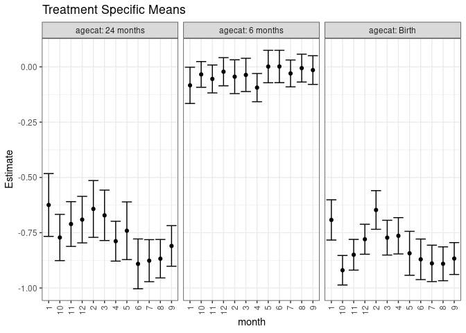

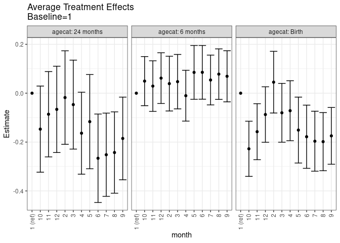

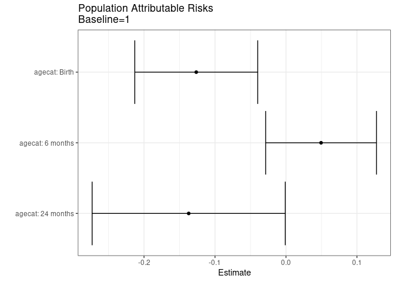

## Results Table

### Parameter: TSM

| agecat | intervention_level | baseline_level | estimate | ci_lower | ci_upper |
| --- | --- | --- | --- | --- | --- |
| Birth | 1 | NA | -0.6921772 | -0.7831376 | -0.6012168 |
| Birth | 2 | NA | -0.6471209 | -0.7345014 | -0.5597404 |
| Birth | 3 | NA | -0.7724198 | -0.8510531 | -0.6937864 |
| Birth | 4 | NA | -0.7638686 | -0.8459613 | -0.6817758 |
| Birth | 5 | NA | -0.8431050 | -0.9425281 | -0.7436819 |
| Birth | 6 | NA | -0.8703650 | -0.9621486 | -0.7785813 |
| Birth | 7 | NA | -0.8886733 | -0.9710140 | -0.8063326 |
| Birth | 8 | NA | -0.8905196 | -0.9671047 | -0.8139344 |
| Birth | 9 | NA | -0.8668059 | -0.9388722 | -0.7947396 |
| Birth | 10 | NA | -0.9197337 | -0.9864448 | -0.8530226 |
| Birth | 11 | NA | -0.8497362 | -0.9192563 | -0.7802161 |
| Birth | 12 | NA | -0.7795264 | -0.8473242 | -0.7117286 |
| 6 months | 1 | NA | -0.0835996 | -0.1655061 | -0.0016930 |
| 6 months | 2 | NA | -0.0444997 | -0.1209079 | 0.0319085 |
| 6 months | 3 | NA | -0.0364448 | -0.1116022 | 0.0387126 |
| 6 months | 4 | NA | -0.0938836 | -0.1576341 | -0.0301332 |
| 6 months | 5 | NA | 0.0014387 | -0.0719714 | 0.0748488 |
| 6 months | 6 | NA | 0.0017412 | -0.0714258 | 0.0749083 |
| 6 months | 7 | NA | -0.0296703 | -0.0903130 | 0.0309724 |
| 6 months | 8 | NA | -0.0056397 | -0.0686512 | 0.0573717 |
| 6 months | 9 | NA | -0.0145329 | -0.0793516 | 0.0502859 |
| 6 months | 10 | NA | -0.0341878 | -0.0922978 | 0.0239222 |
| 6 months | 11 | NA | -0.0546066 | -0.1177077 | 0.0084945 |
| 6 months | 12 | NA | -0.0220117 | -0.0856482 | 0.0416249 |
| 24 months | 1 | NA | -0.6246074 | -0.7666038 | -0.4826110 |
| 24 months | 2 | NA | -0.6425239 | -0.7709536 | -0.5140943 |
| 24 months | 3 | NA | -0.6713598 | -0.7853354 | -0.5573841 |
| 24 months | 4 | NA | -0.7883441 | -0.8783648 | -0.6983234 |
| 24 months | 5 | NA | -0.7410966 | -0.8714597 | -0.6107336 |
| 24 months | 6 | NA | -0.8909314 | -1.0036226 | -0.7782402 |
| 24 months | 7 | NA | -0.8764572 | -0.9715146 | -0.7813998 |
| 24 months | 8 | NA | -0.8674436 | -0.9543299 | -0.7805574 |
| 24 months | 9 | NA | -0.8098439 | -0.9016223 | -0.7180654 |
| 24 months | 10 | NA | -0.7716984 | -0.8762004 | -0.6671964 |
| 24 months | 11 | NA | -0.7107492 | -0.8119422 | -0.6095561 |
| 24 months | 12 | NA | -0.6908192 | -0.7960600 | -0.5855784 |

### Parameter: E(Y)

| agecat | intervention_level | baseline_level | estimate | ci_lower | ci_upper |
| --- | --- | --- | --- | --- | --- |
| Birth | NA | NA | -0.8185873 | -0.8412894 | -0.7958853 |
| 6 months | NA | NA | -0.0341745 | -0.0535053 | -0.0148437 |
| 24 months | NA | NA | -0.7616602 | -0.7929774 | -0.7303431 |

### Parameter: ATE

| agecat | intervention_level | baseline_level | estimate | ci_lower | ci_upper |
| --- | --- | --- | --- | --- | --- |
| Birth | 1 | 1 | 0.0000000 | 0.0000000 | 0.0000000 |
| Birth | 2 | 1 | 0.0450563 | -0.0811882 | 0.1713009 |
| Birth | 3 | 1 | -0.0802425 | -0.2006195 | 0.0401344 |
| Birth | 4 | 1 | -0.0716913 | -0.1943571 | 0.0509744 |
| Birth | 5 | 1 | -0.1509278 | -0.2858320 | -0.0160235 |
| Birth | 6 | 1 | -0.1781877 | -0.3075267 | -0.0488488 |
| Birth | 7 | 1 | -0.1964961 | -0.3192736 | -0.0737185 |
| Birth | 8 | 1 | -0.1983423 | -0.3172885 | -0.0793962 |
| Birth | 9 | 1 | -0.1746286 | -0.2907905 | -0.0584668 |
| Birth | 10 | 1 | -0.2275565 | -0.3404508 | -0.1146621 |
| Birth | 11 | 1 | -0.1575590 | -0.2720953 | -0.0430226 |
| Birth | 12 | 1 | -0.0873492 | -0.2008787 | 0.0261804 |
| 6 months | 1 | 1 | 0.0000000 | 0.0000000 | 0.0000000 |
| 6 months | 2 | 1 | 0.0390999 | -0.0729332 | 0.1511329 |
| 6 months | 3 | 1 | 0.0471548 | -0.0642282 | 0.1585378 |
| 6 months | 4 | 1 | -0.0102841 | -0.1142670 | 0.0936988 |
| 6 months | 5 | 1 | 0.0850383 | -0.0250940 | 0.1951706 |
| 6 months | 6 | 1 | 0.0853408 | -0.0245721 | 0.1952537 |
| 6 months | 7 | 1 | 0.0539293 | -0.0480304 | 0.1558890 |
| 6 months | 8 | 1 | 0.0779598 | -0.0254146 | 0.1813343 |
| 6 months | 9 | 1 | 0.0690667 | -0.0354734 | 0.1736069 |
| 6 months | 10 | 1 | 0.0494118 | -0.0510759 | 0.1498995 |
| 6 months | 11 | 1 | 0.0289930 | -0.0744866 | 0.1324725 |
| 6 months | 12 | 1 | 0.0615879 | -0.0422025 | 0.1653783 |
| 24 months | 1 | 1 | 0.0000000 | 0.0000000 | 0.0000000 |
| 24 months | 2 | 1 | -0.0179166 | -0.2092109 | 0.1733778 |
| 24 months | 3 | 1 | -0.0467524 | -0.2287693 | 0.1352646 |
| 24 months | 4 | 1 | -0.1637367 | -0.3314441 | 0.0039707 |
| 24 months | 5 | 1 | -0.1164893 | -0.3093266 | 0.0763480 |
| 24 months | 6 | 1 | -0.2663240 | -0.4472371 | -0.0854109 |
| 24 months | 7 | 1 | -0.2518498 | -0.4221676 | -0.0815321 |
| 24 months | 8 | 1 | -0.2428363 | -0.4092303 | -0.0764422 |
| 24 months | 9 | 1 | -0.1852365 | -0.3543646 | -0.0161084 |
| 24 months | 10 | 1 | -0.1470910 | -0.3233175 | 0.0291354 |
| 24 months | 11 | 1 | -0.0861418 | -0.2606704 | 0.0883868 |
| 24 months | 12 | 1 | -0.0662118 | -0.2428663 | 0.1104426 |

### Parameter: PAR

| agecat | intervention_level | baseline_level | estimate | ci_lower | ci_upper |
| --- | --- | --- | --- | --- | --- |
| Birth | 1 | NA | -0.1264101 | -0.2129993 | -0.0398209 |
| 6 months | 1 | NA | 0.0494250 | -0.0286468 | 0.1274968 |
| 24 months | 1 | NA | -0.1370528 | -0.2731107 | -0.0009950 |